# BAU Southern Apps

2024-11-19

# Selecting FIA data

For initial exploration of the data, we will first get FIA plots from **AL, GA, KY, NC, SC, TN, and VA**. We are downloading data directly from DataMart for most up to date information. Please modify the above states as necessary. We are then subsetting to ecosections **221, 223, 231, M221**. Again, please modify as necessary.

To clean the data, we are only selecting FIA data that was measured in 1997 or later, when annualized data began. Finally, we are selecting plots that:

1. Have accessible forestland
2. Are not reserves
3. Are of private ownership
4. Are single condition class
5. Are of **Maple / beech / birch group and Oak / hickory group** forest types

# Reporting Harvest likelihoods over 20-year timeframe for major forest types

#### Using the Best Practices formula but with avg time between measurement dates rather than invyr

$$\\[1in]$$

### $\color{forestgreen}{\text{For Maple / beech / birch group the harvest likelihood is: 43.25%}}$

### $\color{forestgreen}{\text{For Oak / hickory group the harvest likelihood is: 31.69%}}$

# Forest Types

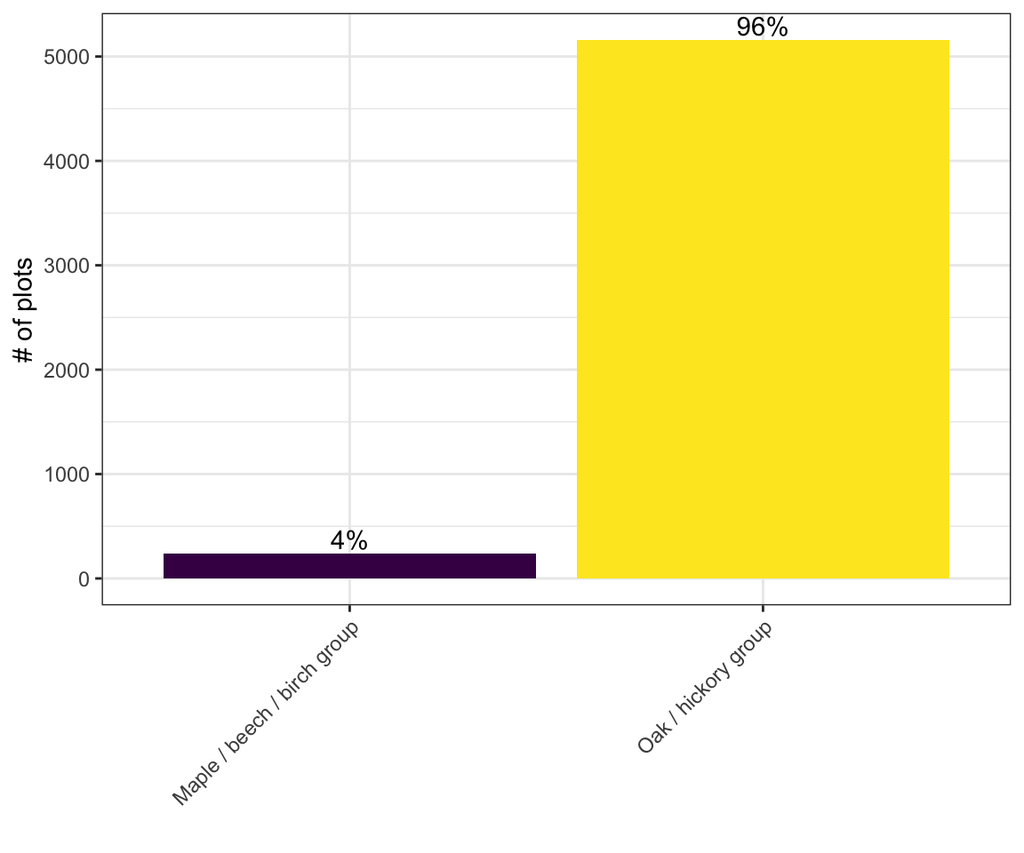

#### Total number of plots is $\color{red}{\text{5398}}$

# Forest transitions over time

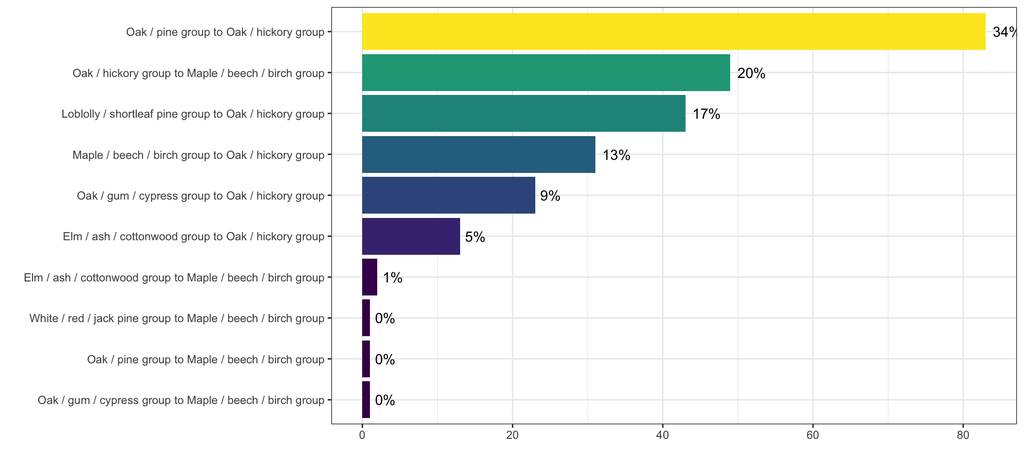

#### Total number of plots that did not transition is $\color{red}{\text{5151}}$

# Breakdown of FIA plots

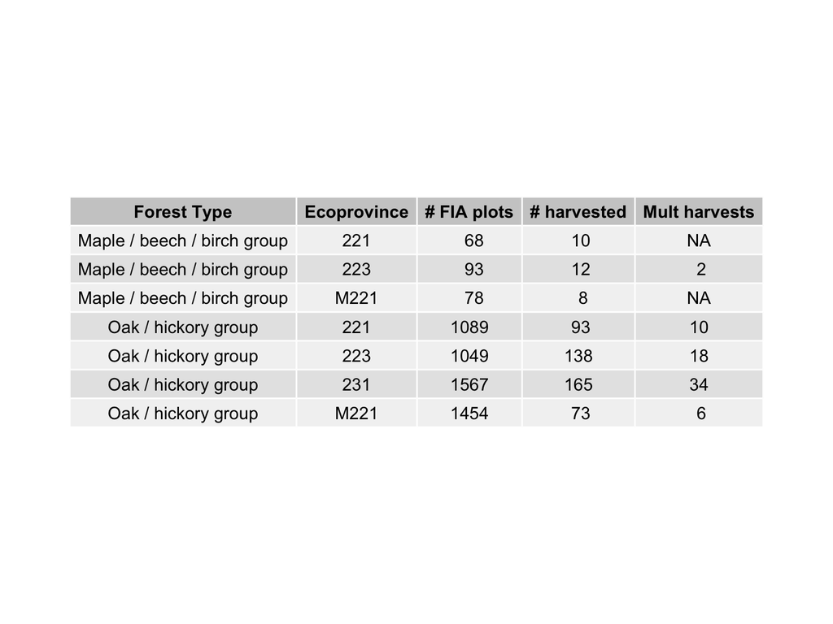

#### This table subsets to sites with *initial* gross board foot volume being greater than or equal to 2000.

# Map of FIA plots

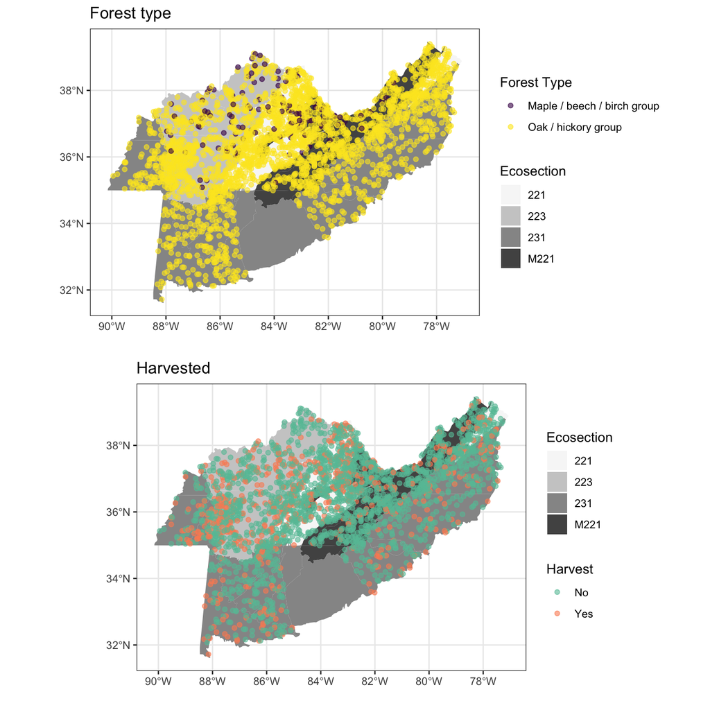

# Change in BAA by forest type

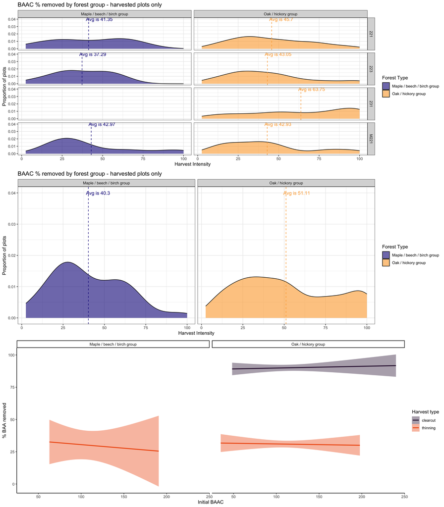

#### $\color{red}{\text{For Maple / beech / birch group, the number of clearcut plots (i.e., removed at least 70% BAAC) is **1** and the number of thinned plots is **29**.}}$

#### $\color{red}{\text{For Oak / hickory group, the number of clearcut plots (i.e., removed at least 70% BAAC) is **126** and the number of thinned plots is **343**.}}$

# Harvest behaviors by change in QMD

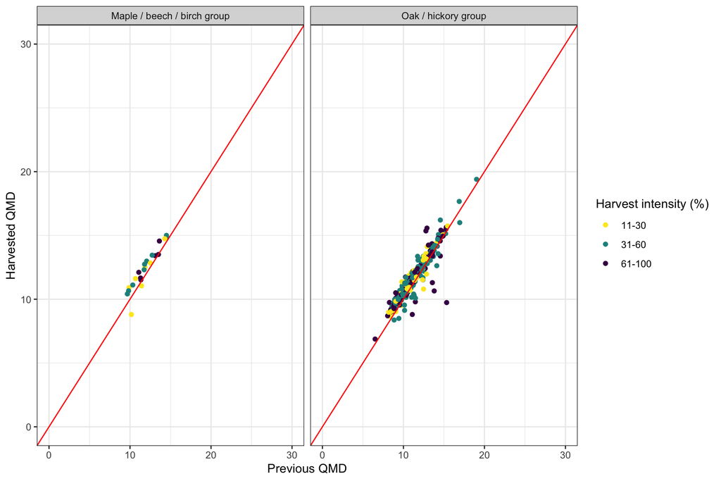

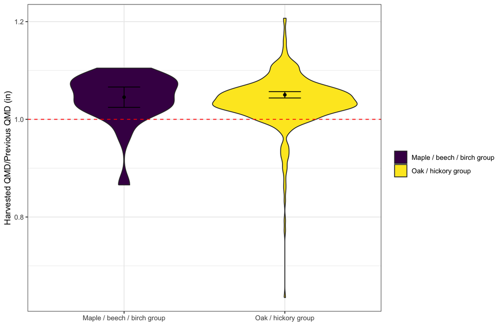

# Percent TPA removed

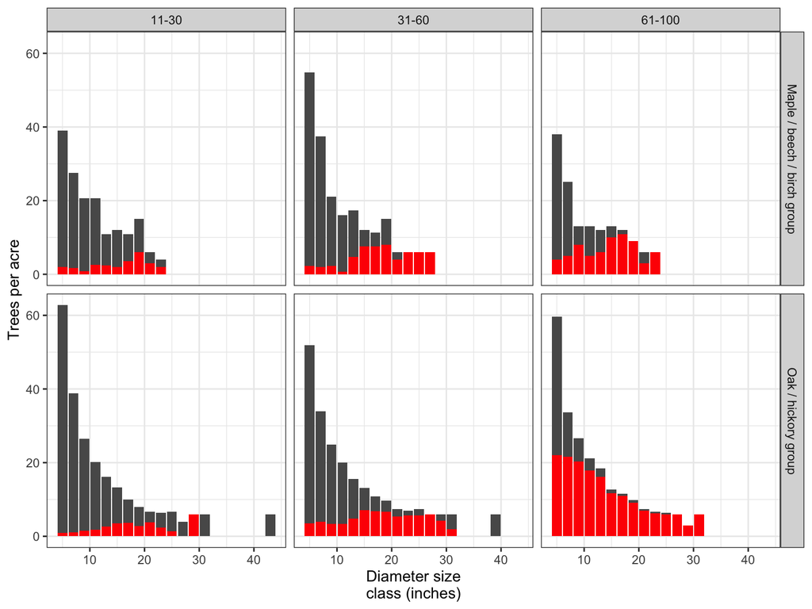

#### The red portions of the histograms represent trees that were removed, whereas the grey portions are the trees left to grow. If the red to grey ratio is consistent across the diameter classes, that suggests a thin throughout. If the red to grey ratio is higher in the higher diameter classes, that suggests a thin from above and if the red to grey ratio is higher in the lower diameter classes, that suggests a thin from below.

# Prefeasibility Estimate of Carbon Gains

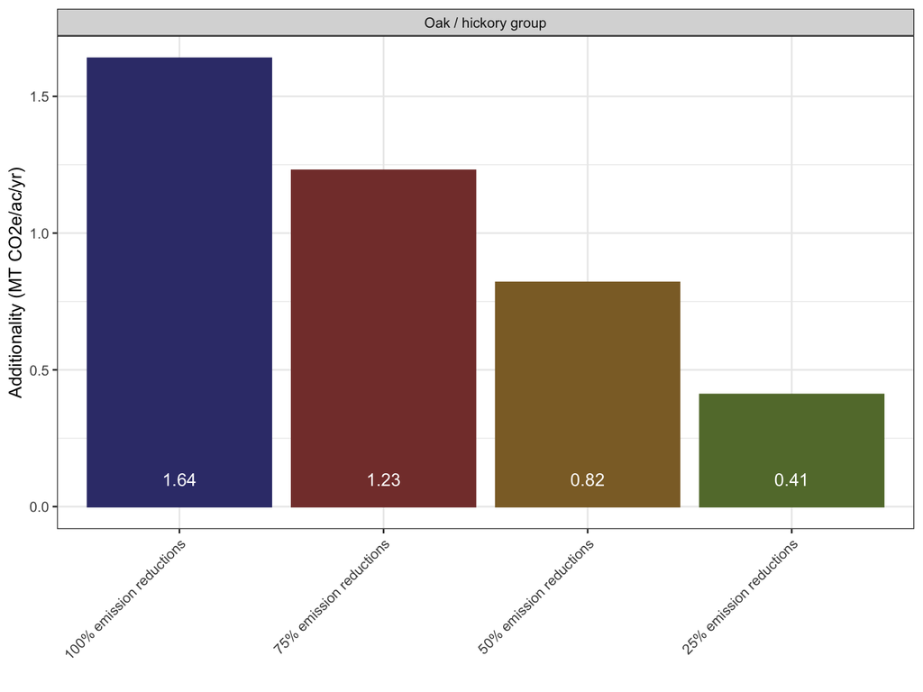